# BGGN239 - Class 1 - Analysis of data from genome-wide association studies

Aditi Jantikar

## Exploring GWAS Summary statistics

GWAS *summary statistics* are computed statistics like p-values and odds-ratios etc. that describe the association between a genetic variant’s genotype and a trait of interest. This differs from *individual level* data, which are the complete set of genotypes and phenotypes for each individual. Summary statistics take up a lot less space, and also don’t have the same privacy concerns that genotype data have.

Read in summary statistics from a genome-wide association study of Rheumatoid Arthritis. These data are from this study: https://www.nature.com/articles/nature12873

```r
gwas.tab <- read.table("RA_GWAS.txt", header=T)
head(gwas.tab)
```

|  | SNP.ID | chrom | chrom.pos.hg19 | genome.pos.hg19 | allele1 | allele2 | p.val |
| --- | --- | --- | --- | --- | --- | --- | --- |
| 1 | rs2799070 | 1 | 949925 | 949925 | T | C | 0.420 |
| 2 | rs9329410 | 1 | 1039268 | 1039268 | T | C | 0.180 |
| 3 | rs36030198 | 1 | 1043900 | 1043900 | T | C | 0.220 |
| 4 | chr1:1163964 | 1 | 1163964 | 1163964 | A | G | 0.014 |
| 5 | chr1:1171836 | 1 | 1171836 | 1171836 | T | C | 0.500 |
| 6 | rs11260576 | 1 | 1210360 | 1210360 | T | C | 0.036 |

Note that these data have been thinned to reduce the size of the dataset for this class. If you are interested in the full dataset, it can be downloaded from here: http://plaza.umin.ac.jp/~yokada/datasource/software.htm

Recent GWAS often include data from >50,000,000 SNPs. How many SNPs are in this data table?

```r
nrow(gwas.tab)
```

```
[1] 100000
```

Let’s take a look at the data. Make a histogram of the p-values.

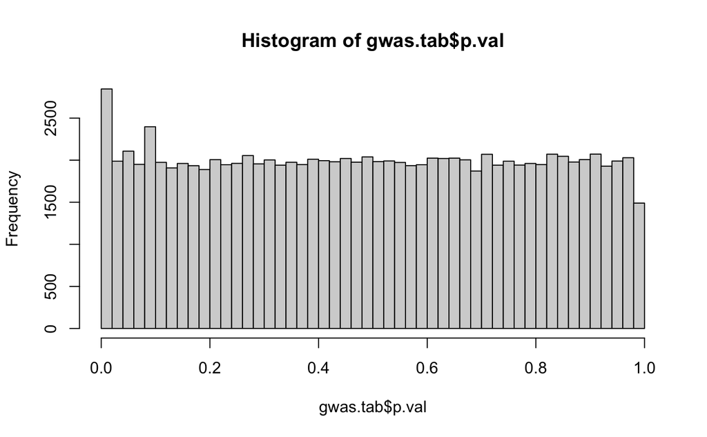

```r
hist(gwas.tab$p.val, breaks=50)
```

Notice that the distribution looks fairly uniform, but with an excess of low p-values.

A quantile-quantile plot provides a better way to see how the distribution deviates from the null-expection of uniformity. In addition, if we use -log10 p-values, we can really see what is going on the low-p-value tail of the distribution. Compare theoretical distribution to observed distribution. runif- randomly sampled uniform distribution norm- normal distribution

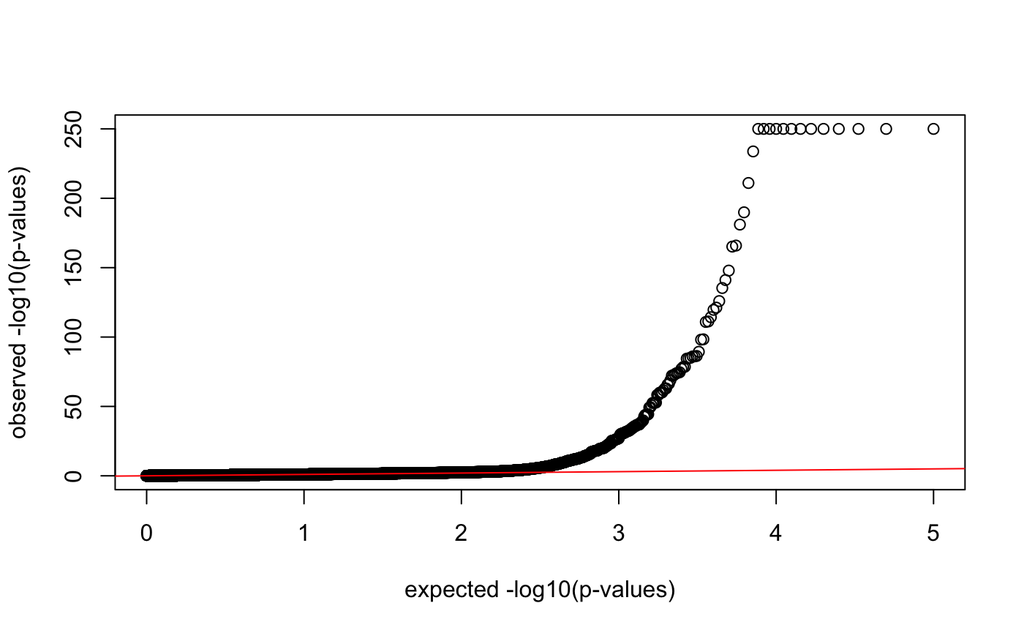

```r
expect.p <- 1:nrow(gwas.tab) / nrow(gwas.tab)
# expect.p <- runif(100000)

obs.p <- gwas.tab$p.val
qqplot(-log10(expect.p), -log10(obs.p),
       xlab="expected -log10(p-values)",
       ylab="observed -log10(p-values)")

## add a line with a slope of 1, to show what the p-values would look
## like if the followed the null distribution
abline(a=0, b=1, col="red")
```

## Make a Manhattan plot

Let’s make a manhattan plot, which shows the association signal across the genome. The big hit is HLA.

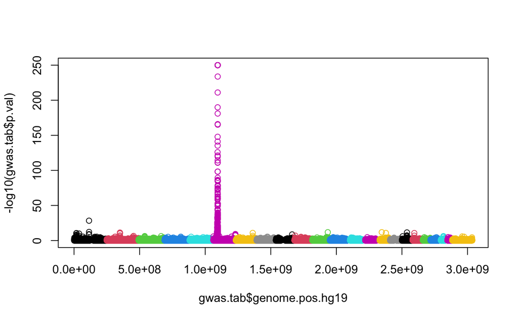

```r
## assign colors to each chromosome
#chrom <- unique(gwas.tab$chrom)
#chrom.color <- rep(c("slategray3", "slategray4"), (length(chrom)+1)/2)
#gwas.tab["color"] <- rep("slategray3", nrow(gwas.tab))
#for(i in seq(1,length(chrom))) {
#  gwas.tab$color[gwas.tab$chrom == chrom[i]] <- chrom.color[i]
#}

#plot(gwas.tab$genome.pos.hg19, -log10(gwas.tab$p.val),
#     col=gwas.tab$color, xlab="genome position", ylab="-log10(P-value)")

plot(gwas.tab$genome.pos.hg19, -log10(gwas.tab$p.val),
     col=as.factor(gwas.tab$chrom))
```

What is the region with the extremely low p-values?

```r
gwas.tab[gwas.tab$p.val < 1e-200,]
```

|  | SNP.ID | chrom | chrom.pos.hg19 | genome.pos.hg19 | allele1 | allele2 | p.val |
| --- | --- | --- | --- | --- | --- | --- | --- |
| 37719 | rs9268474 | 6 | 32357165 | 1094899125 | T | C | 1.0e-250 |
| 37727 | rs2076522 | 6 | 32371179 | 1094913139 | G | C | 1.0e-250 |
| 37729 | rs9268496 | 6 | 32375374 | 1094917334 | A | G | 1.0e-250 |
| 37730 | rs9268507 | 6 | 32377539 | 1094919499 | A | G | 1.0e-250 |
| 37749 | rs9269037 | 6 | 32437958 | 1094979918 | T | C | 1.0e-250 |
| 37752 | rs28752497 | 6 | 32568481 | 1095110441 | A | T | 1.0e-250 |
| 37757 | rs5004279 | 6 | 32582406 | 1095124366 | G | C | 9.6e-212 |
| 37762 | rs9271522 | 6 | 32589791 | 1095131751 | T | C | 1.0e-250 |
| 37774 | rs9275239 | 6 | 32660717 | 1095202677 | A | G | 1.0e-250 |
| 37776 | rs9275314 | 6 | 32665909 | 1095207869 | A | C | 1.0e-250 |

[output cut: 5 more lines]

Let’s zoom in on this region.

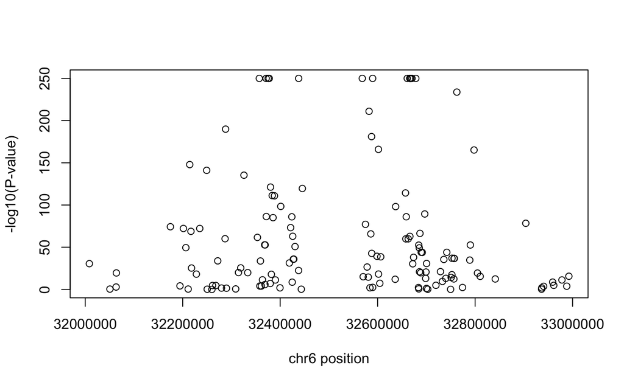

```r
# Make a zoomed-in plot of the p-values just from chromosome 6 32-33MB

f <- which(gwas.tab$chrom=="6" &
           gwas.tab$chrom.pos.hg19 > 32e6 &
           gwas.tab$chrom.pos.hg19 < 33e6)

plot(gwas.tab$chrom.pos.hg19[f], -log10(gwas.tab$p.val[f]),
     xlab="chr6 position", ylab="-log10(P-value)")
```

*Q:* What region is this? Can look in UCSC genome browser

*A:* MHC region

The MHC region has a super low p-value, which obscures other signals. Let’s make the plot again, this time thresholding p-values to 1e-20.

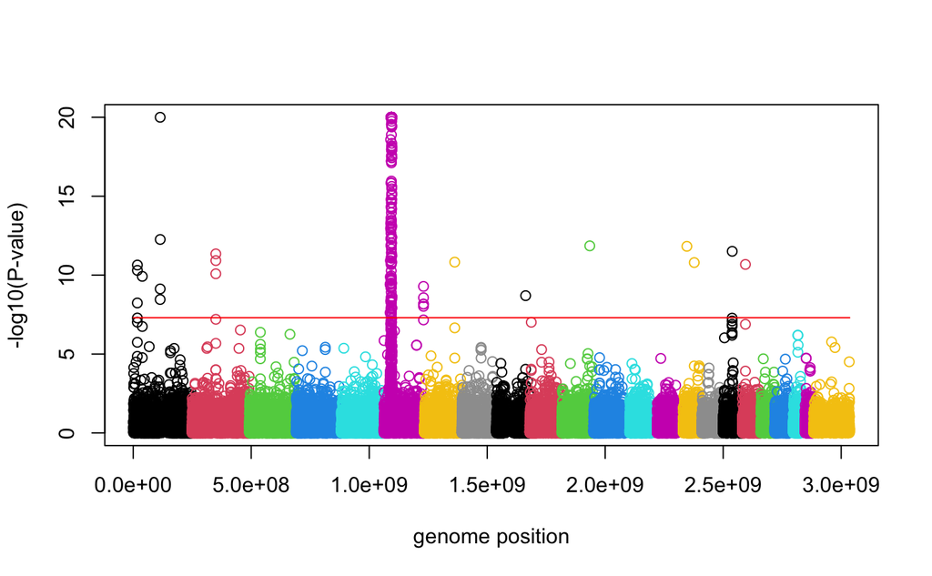

```r
p.val <- gwas.tab$p.val
p.val[p.val < 1e-20] <- 1e-20

plot(gwas.tab$genome.pos.hg19, -log10(p.val),
     col=gwas.tab$chrom, xlab="genome position", ylab="-log10(P-value)",
     ylim=c(0, 20))

# also draw a line indicating the threshold for genome-wide significance (5e-8)
lines(x=c(0, max(gwas.tab$genome.pos.hg19)), y=rep(-log10(5e-8),2), col="red")
```